# New Notebook (1)

```python
import arcpy
import os
walk = arcpy.da.Walk(r"C:\Users\crsab\OneDrive\Documents\Programming\geog4057_Sabin\Assignment7\Ex7",datatype="RasterDataset")
for dirpath, dirnames, filenames in walk:
    for file in filenames:
        print(os.path.join(dirpath, file))
```

```
C:\Users\crsab\OneDrive\Documents\Programming\geog4057_Sabin\Assignment7\Ex7\elevation
C:\Users\crsab\OneDrive\Documents\Programming\geog4057_Sabin\Assignment7\Ex7\landcover.tif
C:\Users\crsab\OneDrive\Documents\Programming\geog4057_Sabin\Assignment7\Ex7\tm.img
```

```python
import arcpy
from arcpy import env
env.workspace = r"C:\Users\crsab\OneDrive\Documents\Programming\geog4057_Sabin\Assignment7\Ex7"
raster1 = "tm.img"
raster2 = "landcover.tif"
raster3 = "elevation"
desc1 = arcpy.da.Describe(raster1)
desc2 = arcpy.da.Describe(raster2)
desc3 = arcpy.da.Describe(raster3)
print(desc1["bandCount"])
print(desc2["bandCount"])
print(desc3["bandCount"])
```

```
3
1
1
```

the bandcount for tm.img is 3, landcover.tif is 1, and elevation is 1

```python
import arcpy
from arcpy import env
env.workspace = r"C:\Users\crsab\OneDrive\Documents\Programming\geog4057_Sabin\Assignment7\Ex7"
raster1 = "tm.img"
raster2 = "landcover.tif"
raster3 = "elevation"
R1bit = arcpy.management.GetRasterProperties("tm.img", "VALUETYPE")
r1BIT = R1bit.getOutput(0)
print(r1BIT)
R2bit = arcpy.management.GetRasterProperties("landcover.tif", "VALUETYPE")
r2BIT = R2bit.getOutput(0)
print(r2BIT)
R3bit = arcpy.management.GetRasterProperties("elevation", "VALUETYPE")
r3BIT = R3bit.getOutput(0)
```

```
3
4
```

Value of 3 for "tm.img" Value Type means that the bit size 3=8-bit unsigned integer. Value of 4 for "landcover.tif" Value Type means that the bit size 4=8-bit signed.

```python
import arcpy
from arcpy import env
env.workspace = r"C:\Users\crsab\OneDrive\Documents\Programming\geog4057_Sabin\Assignment7\Ex7"
raster1 = "tm.img"
raster2 = "landcover.tif"
raster3 = "elevation"
R1X = arcpy.management.GetRasterProperties("tm.img", "CELLSIZEX")
r1X = R1X.getOutput(0)
print(r1X)
R1Y = arcpy.management.GetRasterProperties("tm.img", "CELLSIZEY")
r1Y = R1Y.getOutput(0)
print(r1Y)
R2X = arcpy.management.GetRasterProperties("landcover.tif", "CELLSIZEX")
r2X = R2X.getOutput(0)
print(r2X)
R2Y = arcpy.management.GetRasterProperties("landcover.tif", "CELLSIZEY")
r2Y = R2Y.getOutput(0)
print(r2Y)
R3X = arcpy.management.GetRasterProperties("elevation", "CELLSIZEX")
r3X = R3X.getOutput(0)
print(r3X)
R3Y = arcpy.management.GetRasterProperties("elevation", "CELLSIZEY")
r3Y = R3Y.getOutput(0)
print(r3Y)
```

```
2.77777999999997E-04
2.77777999999997E-04
30
30
30
30
```

The cell size of tm.img is 2.77777999999997E-04^2, the cell size of lancover.tif is 30^2, and the cell size of elevation is 30^2

```python
import arcpy
from arcpy import env

env.workspace = r"C:\Users\crsab\OneDrive\Documents\Programming\geog4057_Sabin\Assignment7\Ex7"

raster1 = "tm.img"
raster2 = "landcover.tif"
raster3 = "elevation"

desc1 = arcpy.Describe(raster1)
spatial_ref1 = desc.spatialReference
desc2 = arcpy.Describe(raster2)
spatial_ref2 = desc.spatialReference
desc3 = arcpy.Describe(raster3)
spatial_ref3 = desc.spatialReference
# Print the spatial reference
print(spatial_ref1.name)
print(spatial_ref2.name)
print(spatial_ref3.name)
```

```
GCS_North_American_1983
GCS_North_American_1983
GCS_North_American_1983
```

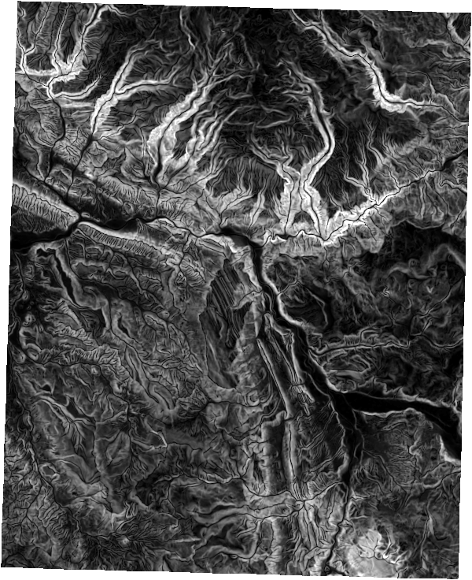

```python
import arcpy
from arcpy.sa import *
elev = arcpy.Raster("elevation")
outraster = Slope(elev)
outraster
```

The elevation is highlighted by lighter values. Values ranging from 0-68.4449 indicate higher slope by lighter values so that the viewer can easily interpret changes in slope. this gives the viewers an idea that the lighter the value, the more steep/quickly the elevation is changing at this point.

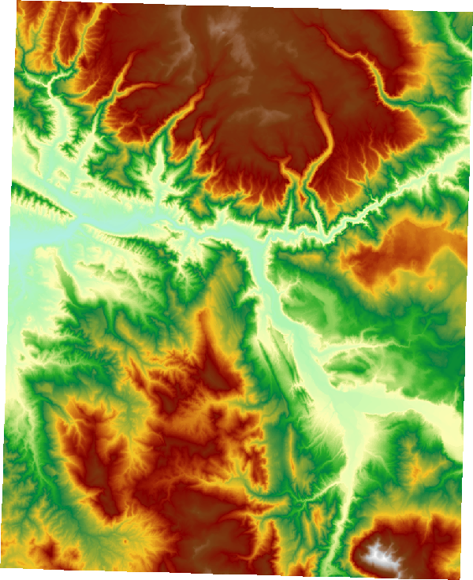

```python
Render (elev, colormap="Elevation #1")
```

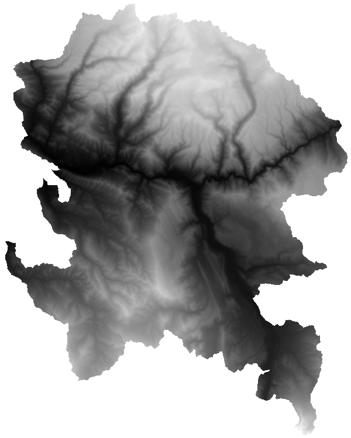

```python
from arcpy.sa import *
from arcpy.ia import *
elev_clip = Clip(elev, "watershed_HUC12.shp")

elev_clip.save("elev_clip")
elev_clip
```

This is the elevation raster clipped to the extant of the watershed. The relevance of this clipped raster is that the raster no longer will contain data(DEM) beyond the influence of the watershed of interest. When studying ecological effects of the watershed it is critical to limit the data input/output to the area of interest

```python
import arcpy
arcpy.env.workspace = r"C:\Users\crsab\OneDrive\Documents\Programming\geog4057_Sabin\Assignment7\Ex7"
landsat = "tm.img"
desc = arcpy.da.Describe(landsat)
for rband in desc["children"]:
    name = rband["name"]
    ras = arcpy.Raster("tm.img" + "/" + name)
    print(ras.catalogPath)
    outreclass.save("lu_reclass")
```

```
C:\Users\crsab\OneDrive\Documents\Programming\geog4057_Sabin\Assignment7\Ex7\tm.img\Layer_1
C:\Users\crsab\OneDrive\Documents\Programming\geog4057_Sabin\Assignment7\Ex7\tm.img\Layer_2
C:\Users\crsab\OneDrive\Documents\Programming\geog4057_Sabin\Assignment7\Ex7\tm.img\Layer_3
```

```python
#(band 3 - band 1) / (band 3 + band 1)

import arcpy
arcpy.env.workspace = r"C:\Users\crsab\OneDrive\Documents\Programming\geog4057_Sabin\Assignment7\Ex7"
from arcpy.sa import *
tm_inras = arcpy.Raster("tm.img")
tm_outras = (tm_inras[2] - tm_inras[0]) / (tm_inras[2] + tm_inras[0])
tm_outras.save("tm_outras")
```

```
---------------------------------------------------------------------------
TypeError                                 Traceback (most recent call last)
In  [83]:
Line 7:     tm_outras = (tm_inras[2] - tm_inras[0]) / (tm_inras[2] + tm_inras[0])

TypeError: The index given is not supported, expected a tuple of 2 or 3 indexes.
---------------------------------------------------------------------------
```

````python
```python
import numpy as np
import arcpy
arcpy.env.workspace = r"C:\Users\crsab\OneDrive\Documents\Programming\geog4057_Sabin\Assignment7\Ex7"
from arcpy.sa import Raster, RasterCellIterator
# read the elevation model
dem = Raster("elevation")
arcpy.env.overwriteOutput = True

#get knowledge about the input raster
raster_info = dem.getRasterInfo()
cell_x = dem.meanCellWidth
cell_y = dem.meanCellHeight

# change the raster info so the output type is 32bit unsigned integer
raster_info.setPixelType("U32")
#create a new raster based on the raster info
elev_relcass = Raster(raster_info)
#update the raster using cell iterator
with RasterCellIterator({'rasters':[dem,elev_reclas]}) as rci:
    for r, c in rci:
    if dem > 2000:
        new_value = 1
    else:
        new_value = 0
slopecon.save()
        # modify this block here to do the classification of elevation to 1 or 0

elev_relcass.save('elev_relcass')
```
````

```
---------------------------------------------------------------------------
SyntaxError                               Traceback (most recent call last)
File C:\Users\crsab\anaconda3\envs\ArcClone\Lib\ast.py, in parse:
Line 50:    return compile(source, filename, mode, flags,

SyntaxError: invalid syntax (<string>, line 1)
---------------------------------------------------------------------------
```

```python
import numpy as np
import arcpy
from arcpy.sa import Raster, RasterCellIterator
# read the elevation model
dem = Raster("elevation")
arcpy.env.overwriteOutput = True
```

```python
#get knowledge about the input raster
raster_info = dem.getRasterInfo()
cell_x = dem.meanCellWidth
cell_y = dem.meanCellHeight
```

```python
raster_info.setPixelType("U32")
```

```python
elev_relcass = Raster(raster_info)
```

```
C:\Users\crsab\AppData\Local\Temp\ArcGISProTemp37100\{50E14187-04F8-4686-8C7E-6D5FC51DCDA8}3710031264.tif
```

```python
arcpy.env.workspace = r"C:\Users\crsab\OneDrive\Documents\Programming\geog4057_Sabin\Assignment7\Ex7"
with RasterCellIterator({'rasters':[dem,elev_reclas]}) as rci:
    for row, col, values in rci:
        elevation = values[0]  # Access the elevation value from the first raster (dem)
        if elevation > 2000:
            new_value = 1
        else:
            new_value = 0
        values[1] = new_value
```

```
---------------------------------------------------------------------------
ValueError                                Traceback (most recent call last)
In  [105]:
Line 3:     for row, col, values in rci:

ValueError: not enough values to unpack (expected 3, got 2)
---------------------------------------------------------------------------
```

```python
import arcpy
import numpy
arcpy.env.workspace = r"C:\Users\crsab\OneDrive\Documents\Programming\geog4057_Sabin\Assignment7\Ex7"
elev_raster = "elevation"
array = arcpy.RasterToNumPyArray(elev_raster)
print(array.min())
print(array.max())
print(array.mean())
print(array.std())
```

```
-3.4028235e+38
3942.4353
-inf
inf
```

NumPyArray is a convenient simplified way to provide dataset values, dataset statistics, etc for data layers; similar to highlighting a column in attribute table and using the calculate statistics interface.